# “Code for: **The temperature-size ‘rule’ and its underlying mechanisms are not universal: evidence from New Zealand stick insects**”

2026-05-15

This documents describes the analyses to investigate the processes behind and realized pattern of temperature-size rule (TSR) across 8 species of stick insects.

# Prep

Load packages

```r
x <-
  c(
    "tidyverse",
    "phangorn",
    "ggplot2",
    "wesanderson",
    "coda",
    "MCMCglmm",
    "ggtree",
    "ggtreeExtra",
    "caper",
    "viridis",
    "kableExtra",
    "ape",
    "phytools",
    "gridExtra",
    "ggh4x"
  )

lapply(x, function(y) {
  # check if installed, if not install
  if (!y %in% installed.packages()[, "Package"])
    install.packages(y)

  # load package
  try(require(y, character.only = T), silent = T)
})
```

Load custom functions and create global variables.

```r
script_fp <- "./"
source(paste0(script_fp, "TSR_utils.R"))

dat_fp <-"../data/raw/"

# read tree
tre <- read.tree(paste0(dat_fp, "stick_tree.tre"))

# fix rounding to ensure ultrametric
tre<-nnls.tree(cophenetic(tre),tre, method = "ultrametric")

# phylogenetic distance matrix
inv.phylo<-inverseA(tre,nodes="TIPS",scale=TRUE)

# standard prior for residual variance (R) and parameter expanded prior for random effect
pr1 = list(R=list(V=1,nu = 0.002),
               G =list(G1=list(V=diag(1),nu=1000,alpha.mu=rep(0,1),alpha.V=diag(1)),
                       G2=list(V=diag(1),nu=1000,alpha.mu=rep(0,1),alpha.V=diag(1))))

# define MCMC parameters
post_n <- 3000
burnin <- 30000
thin <- 100

# define colors
pal <- c("dodgerblue3", "firebrick3")
```

Read in data

```r
dat <- read.csv(paste0(dat_fp, "Relabeled_data_TSR.csv"), header = T, sep = ",")

#head(dat)
```

# By stage

First, let’s look at growth rate trajectories

```r
gdat <-  read.csv(paste0(dat_fp, "growth_rate_data.csv"), header = T, sep = ",")
gdat <- gdat %>% filter(instar != "7") %>% unite(fill, c("instar","test_temp"), remove = FALSE)

# remove outlier with negative growth
outlier <- which(gdat$full_id == "AXG-BG-4")

gdat <- gdat[-outlier,]

# get N values per species and treatment

gdat %>% group_by(species, test_temp) %>%
  summarise(N = length(unique(full_id))) %>% kbl() %>%
  kable_styling(
    bootstrap_options = c("striped", "hover", "condensed"),
    full_width = FALSE,
    position = "center",
    font_size = 12
  )
```

| species | test_temp | N |
| --- | --- | --- |
| ASN | 10 | 6 |
| ASN | 20 | 5 |
| AXG | 10 | 8 |
| AXG | 20 | 6 |
| AXI | 10 | 2 |
| AXI | 20 | 3 |
| CLH | 10 | 8 |
| CLH | 20 | 7 |
| MS2 | 10 | 4 |
| MS2 | 20 | 4 |
| SPA | 10 | 5 |
| SPA | 20 | 6 |
| TTH | 10 | 5 |
| TTH | 20 | 6 |
| TTS | 10 | 5 |
| TTS | 20 | 6 |

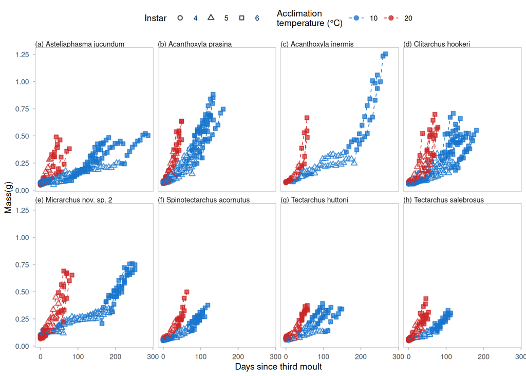

```r
species_names <- c(
  'ASN'="(a) Asteliaphasma jucundum",
  'AXG'="(b) Acanthoxyla prasina",
  'AXI'="(c) Acanthoxyla inermis",
  'CLH'="(d) Clitarchus hookeri",
  'MS2'="(e) Micrarchus nov. sp. 2",
  'SPA'="(f) Spinotectarchus acornutus",
  'TTH'="(g) Tectarchus huttoni",
  'TTS'="(h) Tectarchus salebrosus"

)

p0 <- ggplot(data = gdat, aes(y = weight, x = days_cumulative, color = as.factor(test_temp), shape = as.factor(instar), fill = as.factor(fill))) +
  geom_point(size = 1.5, alpha = 0.7, stroke = 0.7) +
   geom_line(lty =2, linewidth = 0.3, aes(group = full_id)) +
  facet_wrap(~species, nrow = 2 , labeller=as_labeller(species_names), scales = "fixed") +
  scale_color_manual(values = pal) +
  scale_shape_manual(values = c(21,24,22)) +
  scale_fill_manual(values = c(pal[1], pal[2], "white", "white", pal[1], pal[2]), guide = "none") +
  theme_minimal(base_size = 8.5) +
  theme(legend.position = "top", panel.grid = element_blank(), panel.border = element_rect(color = "gray"), axis.ticks = element_line(color = "grey")) +
  theme(strip.text.x = element_text(hjust = 0, margin=margin(l=0)))+
  labs(y = "Mass(g)", x = "Days since third moult", color = "Acclimation \ntemperature (\u00B0C)", shape = "Instar")

p0
```

```r
#ggsave("../output/Growth_trajectories.pdf", p0, device = "pdf", width = 180, height = 120, units = "mm", dpi = 600)
```

Let’s also look at the contribution of each instar to total growth (mass at the end of final instar).

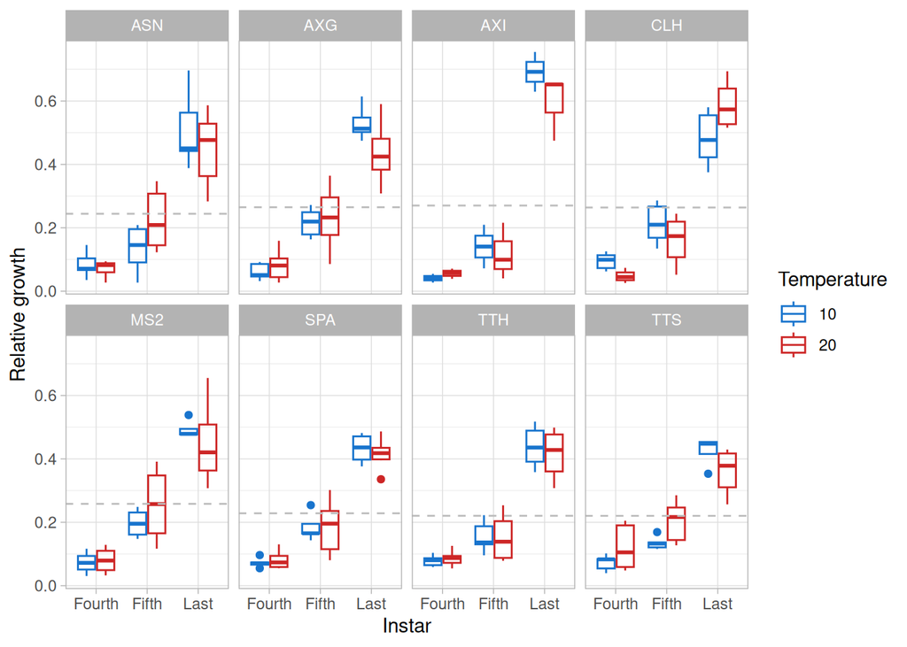

```r
Rel_growth <- dat %>% mutate(Exp_growth = Initial.mass + Mass.last.instar) %>%
  mutate(Fourth.rel.growth = Mass.gain.fourth.instar / Exp_growth,
         Fifth.rel.growth = Mass.gain.fifth.instar / Exp_growth,
         Last.rel.growth = Mass.gain.last.instar / Exp_growth) %>%
  dplyr::select(full_id, species, acclimation, contains("rel")) %>%
  pivot_longer(cols = contains("rel"), names_to = "Instar", values_to = "Rel_growth") %>%
  mutate(Instar = gsub(".rel.growth", "", Instar))

outlier <- which(Rel_growth$full_id == "AXG-BG-4" & Rel_growth$Instar == "Fourth")
Rel_growth <- Rel_growth[-outlier,]

outlier <- which(Rel_growth$Rel_growth < 0)
Rel_growth <- Rel_growth[-outlier,]

Rel_growth$Instar <- factor(Rel_growth$Instar,
                                     levels = c("Fourth", "Fifth", "Last"))

ave_RG <- aggregate(Rel_growth$Rel_growth, by = list(Rel_growth$species), FUN = mean, na.rm = T)
colnames(ave_RG)[1] <- "species"


rg <- ggplot(Rel_growth, aes(x = Instar, y = Rel_growth, colour = as.factor(acclimation))) +
   #geom_jitter(size = 2, width = 0.2) +
   geom_boxplot(fill = NA) +
    geom_hline(data = ave_RG, aes(yintercept = x), color = "gray", lty = 2) +
    scale_color_manual(values = pal[1:2]) +
    # species to separate panels
    facet_wrap(~species, ncol = 4) +
    theme_light() +
  labs(color = "Temperature", y = "Relative growth")

rg
```

```r
#ggsave("~/Dropbox/Collaborations/TSR/Rel_growth.pdf", rg, device = "pdf", width = 180, height = 120, units = "mm", dpi = 600)
```

We first look at the DDG processes (thermal sensitivity of developmental and growth rates) and realized patterns (differences in mass between rearing temperatures) for each developmental stage from fourth instar nymph to end of the last instar.

```r
# Create variables for starting mass
dat$StartM.fourth.instar <- dat$Initial.mass
dat$StartM.fifth.instar <- dat$Mass.fourth.instar
dat$StartM.last.instar <- dat$Mass.fifth.instar

# we don't need the mass.gain variables
dat_l <- dat %>% dplyr::select(!contains("Mass.gain.")) %>%
  dplyr::select(!contains("imago")) %>%
  # change variable names to simplify regular expressions
  rename_with( ~ str_remove_all(.x, ".instar")) %>%
  rename_with( ~ str_remove_all(.x, ".Instar")) %>%
  # pivot to longer format to put all instars into a single column
  pivot_longer(
    cols = starts_with("Days") |
      starts_with("DR") |
      starts_with("StartM") | starts_with("Mass") | starts_with("GR"),
    names_to = c("Trait", "Instar"),
    values_to = "Value",
    names_pattern = "(.*)\\.(.*)"
  ) %>%
  # pivot to wider to separate traits
  pivot_wider(names_from = Trait, values_from = Value) %>%
   mutate(Instar = fct_recode(as.factor(Instar),
    "sixth" = "last"
  ))

# remove the individual whose mass increased 14x in the fourth instar
outlier <- which((dat_l$full_id == "AXG-BG-4" & dat_l$Instar == "fourth") | (dat_l$full_id == "AXG-BG-4" & dat_l$Instar == "fifth"))

dat_l <- dat_l[-outlier,]
```

## Growth and Development

To better understand the results from development-growth rate differentials we’ll plot the raw growth and development rates, for each stage and species.

### Data prep

Data prep for final figures

```r
ave_DR <- aggregate(dat_l$DR, by = list(dat_l$species), FUN = mean, na.rm = T)
colnames(ave_DR)[1] <- "species"


# 1. Calculate the grouped averages
# Create a summary dataframe with one row per group
df_full_proc <- dat_l %>%
  group_by(full_id) %>%
  summarise(
    DR = mean(DR, na.rm = TRUE),
    GR =  mean(GR, na.rm = TRUE),
    Mass = mean(Mass, na.rm = TRUE),
    species = species,
    acclimation = acclimation,
    # Add a label for the average row, ensuring the column type matches
    # other columns (e.g., using 'Avg' for a character column)
    .groups = 'drop' # Recommended to drop groups after summarizing
  ) %>%
  # Add a new column to indicate this is the average row
  mutate(Instar = "all") %>%
  mutate(Data = "full")


# 2. Add a label column to the original data frame for consistency before binding
df_labeled <- dat_l  %>%
  mutate(Data = "stage")

# 3. Combine the original data and the average rows
# The bind_rows function combines the data frames by column name
df_combined <- bind_rows(df_labeled, df_full_proc) %>%
  # Optional: sort the results by group_col and then by label
  arrange(species, acclimation, desc(Instar))


summary_DR <- df_combined %>%
  group_by(species, acclimation, Instar) %>%
  summarise(
    mean_DR = mean(DR),
    sd_DR = sd(DR, na.rm = T),
    ymin_DR = mean_DR - sd_DR, # Lower bound
    ymax_DR = mean_DR + sd_DR, # Upper bound
    .groups = 'drop'
  )

summary_GR <- df_combined %>%
  group_by(species, acclimation, Instar) %>%
  summarise(
    mean_GR = mean(GR),
    sd_GR = sd(GR, na.rm = T),
    ymin_GR = mean_GR - sd_GR, # Lower bound
    ymax_GR = mean_GR + sd_GR, # Upper bound
    .groups = 'drop'
  )

summary_Mass <- df_combined %>%
  group_by(species, acclimation, Instar) %>%
  summarise(
    mean_Mass = mean(Mass),
    sd_Mass = sd(Mass, na.rm = T),
    ymin_Mass = mean_Mass - sd_Mass, # Lower bound
    ymax_Mass = mean_Mass + sd_Mass, # Upper bound
    .groups = 'drop'
  )


species_names <- c(
  'ASN'="(a) Asteliaphasma jucundum",
  'AXG'="(b) Acanthoxyla prasina",
  'AXI'="(c) Acanthoxyla inermis",
  'CLH'="(d) Clitarchus hookeri",
  'MS2'="(e) Micrarchus nov. sp. 2",
  'SPA'="(f) Spinotectarchus acornutus",
  'TTH'="(g) Tectarchus huttoni",
  'TTS'="(h) Tectarchus salebrosus"

)


df_combined$Instar <- factor(df_combined$Instar,
                            levels = c("fourth", "fifth", "sixth", "all"))


myLoc <-
  (which(levels(df_combined$Instar) == "sixth") +
     which(levels(df_combined$Instar) == "all")) /
  2
```

### Development rate

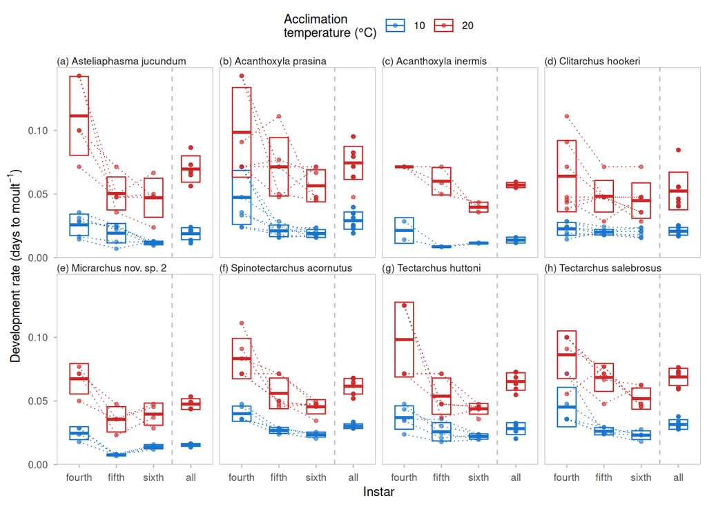

```r
p1 <- ggplot(data = df_combined, aes(y = DR, x = Instar, color = as.factor(acclimation))) +
  geom_point(size = 1, alpha = .6) +
    geom_line(lty =3, linewidth = 0.3, data = dat_l, aes(group = full_id)) +
  geom_crossbar(data = summary_DR, aes(y = mean_DR, ymin = ymin_DR, ymax = ymax_DR), width = 0.5) +
  geom_vline(aes(xintercept = myLoc), color = "gray", lty = 2) +
  facet_wrap(~species, nrow = 2 , labeller=as_labeller(species_names)) +
  scale_color_manual(values = pal) +
  theme_minimal(base_size = 9) +
  theme(legend.position = "top", panel.grid = element_blank(), panel.border = element_rect(color = "gray"), axis.ticks = element_line(color = "grey")) +
  labs(y = bquote('Development rate (days to '*moult^-1*')'), x = "Instar", color = "Acclimation \ntemperature (\u00B0C)") +
  theme(strip.text.x = element_text(hjust = 0, vjust = 1, margin=margin(l=0)))

p1
```

```r
#ggsave("../output/Raw_DR.pdf", p1, device = "pdf", width = 180, height = 120, units = "mm", dpi = 600)
```

Reaction norm of development rate for insets

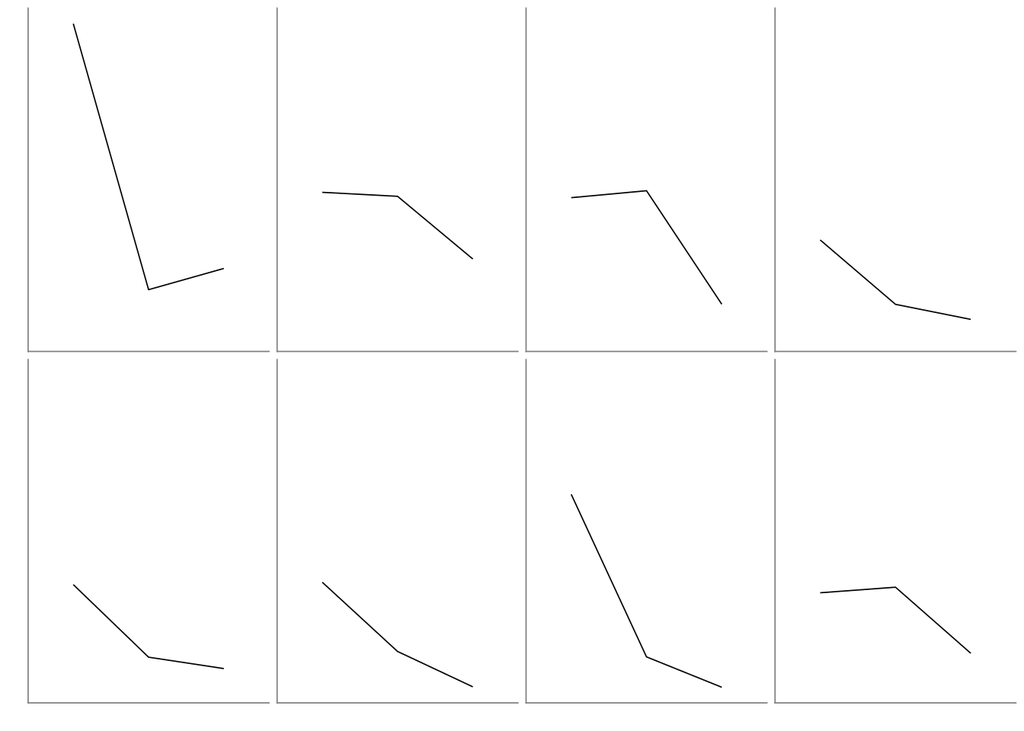

```r
df_rxn <- dat_l %>%
  group_by(species, acclimation, Instar) %>%
  summarise(
    mean_DR = mean(DR, na.rm = T),
    mean_GR = mean(GR, na.rm = T),
    .groups = 'drop'
  )   %>%
  pivot_wider(names_from = c(acclimation), values_from = c(mean_DR, mean_GR)) %>%
  mutate(DR_rxn = mean_DR_20 - mean_DR_10,
         GR_rxn = mean_GR_20 - mean_GR_10)

df_rxn$Instar <- factor(df_rxn$Instar,
                            levels = c("fourth", "fifth", "sixth"))


p1.1 <- ggplot(data = df_rxn, aes(y = DR_rxn, x = Instar)) +
  geom_line(lty =1, linewidth = 0.3,  aes(group = species)) +
  #geom_point(size = 1) +
   facet_wrap2(~species, nrow = 2, labeller=as_labeller(species_names),, axes = "all") +
  theme_classic(base_size = 8) +
  theme(panel.grid = element_blank(),
  strip.text = element_blank(),
  strip.background = element_blank(),
  axis.text = element_blank(),
  axis.ticks = element_blank(),
   axis.line = element_line(color = "grey50", linewidth = 0.3, linetype = "solid")) +
  labs(y = "", x = "")


p1.1
```

```r
#ggsave("../output/Raw_DR_insets.pdf", p1.1, device = "pdf", width = 64, height = 32, units = "mm", dpi = 600)
```

### Growth rate

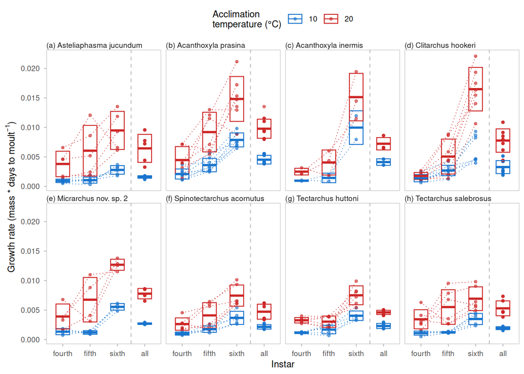

```r
ave_GR <-  aggregate(dat_l$GR, by = list(dat_l$species), FUN = mean, na.rm = T)
colnames(ave_GR)[1] <- "species"

p2 <-  ggplot(data = df_combined, aes(y = GR, x = Instar, color = as.factor(acclimation))) +
  geom_point(size = 1, alpha = .6) +
    geom_line(lty =3, linewidth = 0.3, data = dat_l, aes(group = full_id)) +
  geom_crossbar(data = summary_GR, aes(y = mean_GR, ymin = ymin_GR, ymax = ymax_GR), width = 0.5) +
  geom_vline(aes(xintercept = myLoc), color = "gray", lty = 2) +
  facet_wrap(~species, nrow = 2 , labeller=as_labeller(species_names)) +
  scale_color_manual(values = pal) +
  theme_minimal(base_size = 9) +
  theme(legend.position = "top", panel.grid = element_blank(), panel.border = element_rect(color = "gray"), axis.ticks = element_line(color = "grey")) +
  labs(y = bquote('Growth rate (mass * days to '*moult^-1*')'), x = "Instar", color = "Acclimation \ntemperature (\u00B0C)") +
  theme(strip.text.x = element_text(hjust = 0, vjust = 1, margin=margin(l=0)))

p2
```

```r
#ggsave("../output/Raw_GR.pdf", p2, device = "pdf", width = 180, height = 120, units = "mm", dpi = 600)
```

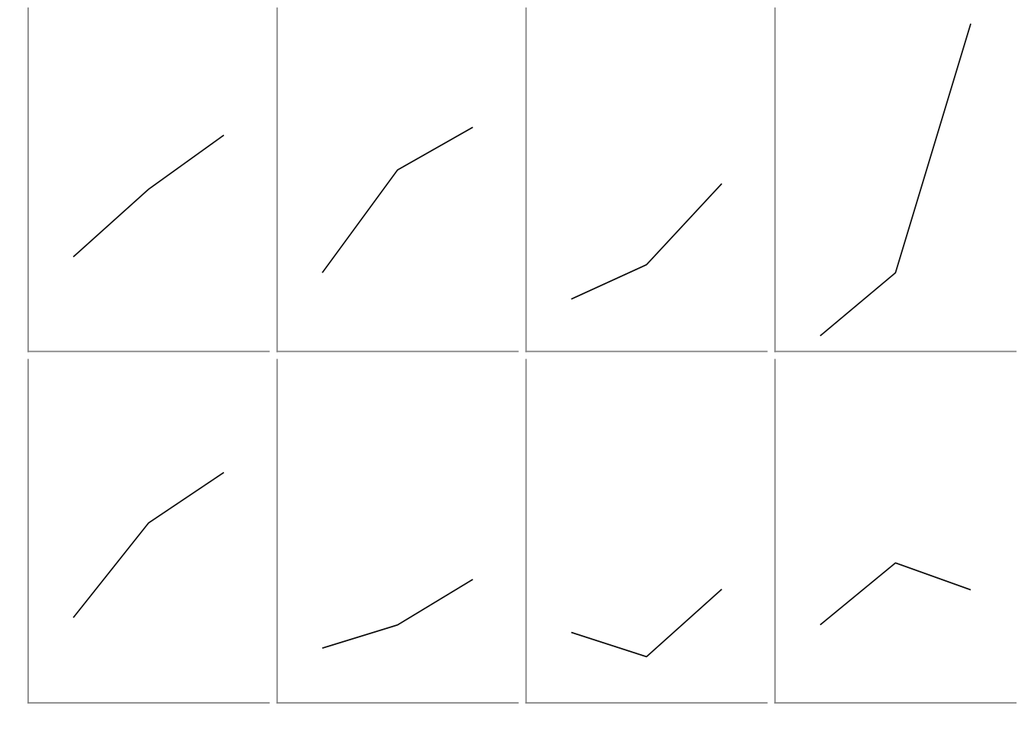

```r
p2.1 <- ggplot(data = df_rxn, aes(y = GR_rxn, x = Instar)) +
  geom_line(lty =1, linewidth = 0.3,  aes(group = species)) +
  #geom_point(size = 1) +
   facet_wrap2(~species, nrow = 2, labeller=as_labeller(species_names),, axes = "all") +
  theme_classic(base_size = 8) +
  theme(panel.grid = element_blank(),
  strip.text = element_blank(),
  strip.background = element_blank(),
  axis.text = element_blank(),
  axis.ticks = element_blank(),
   axis.line = element_line(color = "grey50", linewidth = 0.3, linetype = "solid")) +
  labs(y = "", x = "")


p2.1
```

```r
#ggsave("../output/Raw_GR_insets.pdf", p2.1, device = "pdf", width = 64, height = 32, units = "mm", dpi = 600)
```

## Thermal sensitivity of development and growth rates

Center and scale rate variables to make them comparable. This also removes two data points with instantaneous development.

```r
dat_l_proc <- prep_rate_dat (data = dat_l, group =list(dat_l$species), dev_rate=dat_l$DR, growth_rate = dat_l$GR)

dat_l_proc$Instar <- factor(dat_l_proc$Instar,
                                     levels = c("fourth", "fifth", "sixth"))# Plotting acclimation as continuous to
```

### Analysis

Estimate species, instar, and trait-specific slopes with MCMCglmm. “acclimation” is treated as a factor, so we will obtain posterior distributions for rates at 10 and 20 C, and then compute their difference to obtain a posterior distribution for each trait-specific slope.

```r
# MCMCglmm hates tibble
class(dat_l_proc) <- "data.frame"

# acclimation as factor
dat_l_proc$acclimation <- as.factor(dat_l_proc$acclimation)

# we are not interested in fixed effects per se
m1 <- MCMCglmm(value ~ species:Instar:rate:acclimation - 1,
               # but we want to estimate species-specific rates at each temperature
               random = ~ species + full_id,
               ginverse=list(species=inv.phylo$Ainv),
               # assuming here that the errors follow a normal distr
               family = "gaussian",
               data = dat_l_proc,
               prior = pr1,
               pl = TRUE,
               slice = TRUE,
               nitt = post_n*thin + burnin,
               burnin = burnin,
               thin = thin,
               verbose = F
)
```

Quick mcmc diagnostics – everything looks good enough, not printing results

### Processing output

Organize and compute posterior distributions of interest.

```r
post_final <- process_rate_glmm(mcmc = m1$Sol, post_n = post_n, n_species = 8, n_stages =3, n_traits = 2, n_temp = 2)

post_final$instar <- factor(post_final$instar,
                                     levels = c("fourth", "fifth", "sixth"))
#head(post_final)
```

Plot posterior distributions of reaction norm differences between developmental and growth rates. Positive values indicate a growth/development process consistent with TSR.

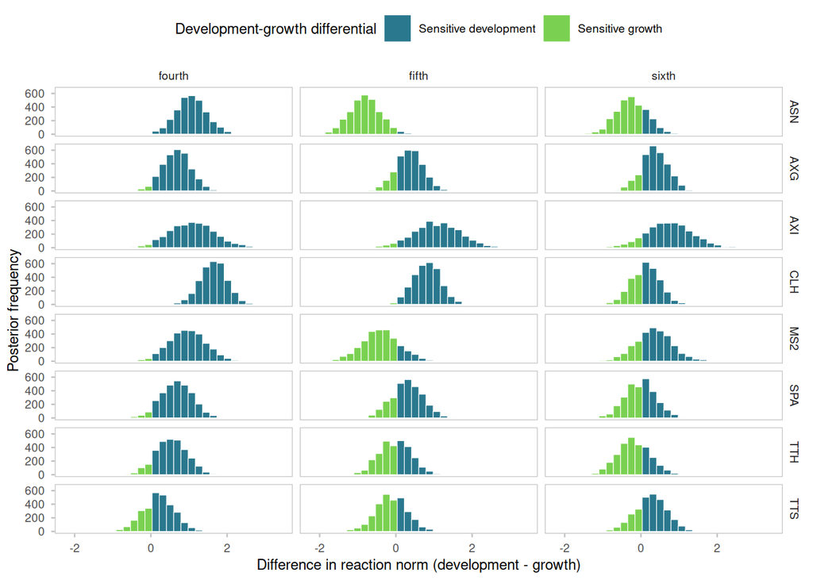

```r
process_within_p <- plot_posteriors(
  data = post_final,
  x = post_final$rule,
  colors = "D",
  x_label = "Difference in reaction norm (development - growth)",
  low_label = "Sensitive development",
  high_label = "Sensitive growth",
  main = "Development-growth differential"
)

process_within_p
```

```r
#ggsave("../output/process_within_posteriors.pdf", process_within_p, device = "pdf", width = 180, height = 200, units = "mm", dpi = 600)
```

Compute support

```r
post_summ <- post_final %>% group_by(species,instar) %>%
  summarise(mean = mean(dev - growth),
            lwr = HPDinterval(mcmc(dev - growth))[1],
            upr = HPDinterval(mcmc(dev - growth))[2],
            P_tsr = sum((dev - growth) < 0)/3000) # probability of opposite to TSR

post_summ %>% kbl(digits=3) %>%
  kable_styling(
    bootstrap_options = c("striped", "hover", "condensed"),
    full_width = FALSE,
    position = "center",
    font_size = 12
  )
```

| species | instar | mean | lwr | upr | P_tsr |
| --- | --- | --- | --- | --- | --- |
| ASN | fourth | 1.058 | 0.332 | 1.931 | 0.004 |
| ASN | fifth | -0.804 | -1.587 | -0.027 | 0.974 |
| ASN | sixth | -0.240 | -1.006 | 0.538 | 0.724 |
| AXG | fourth | 0.671 | -0.026 | 1.379 | 0.034 |
| AXG | fifth | 0.344 | -0.378 | 1.002 | 0.170 |
| AXG | sixth | 0.352 | -0.302 | 1.044 | 0.154 |
| AXI | fourth | 1.078 | 0.012 | 2.392 | 0.034 |
| AXI | fifth | 1.074 | -0.188 | 2.213 | 0.045 |
| AXI | sixth | 0.730 | -0.474 | 1.884 | 0.115 |
| CLH | fourth | 1.643 | 0.950 | 2.313 | 0.000 |
| CLH | fifth | 0.807 | 0.100 | 1.466 | 0.009 |
| CLH | sixth | 0.118 | -0.583 | 0.805 | 0.371 |
| MS2 | fourth | 0.953 | 0.048 | 1.901 | 0.023 |
| MS2 | fifth | -0.393 | -1.306 | 0.613 | 0.803 |
| MS2 | sixth | 0.331 | -0.576 | 1.290 | 0.244 |
| SPA | fourth | 0.670 | -0.159 | 1.424 | 0.049 |
| SPA | fifth | 0.286 | -0.529 | 1.039 | 0.239 |
| SPA | sixth | -0.012 | -0.752 | 0.753 | 0.510 |
| TTH | fourth | 0.529 | -0.277 | 1.276 | 0.097 |
| TTH | fifth | -0.018 | -0.717 | 0.840 | 0.517 |
| TTH | sixth | -0.185 | -0.994 | 0.613 | 0.677 |
| TTS | fourth | 0.198 | -0.629 | 0.966 | 0.306 |
| TTS | fifth | -0.111 | -0.951 | 0.631 | 0.606 |
| TTS | sixth | 0.254 | -0.596 | 0.998 | 0.267 |

```r
# write to csv
#write.table(post_summ, file = "../output/TSR_process_stage_summary.csv", quote = F, row.names = F, sep = ",")
```

Estimate contrasts

```r
# between acclimation temperatures
temp_cont <- post_final %>% group_by(species,instar) %>%
  summarise(mean_dev = mean(dev),
            lwr_dev = HPDinterval(mcmc(dev))[1],
            upr_dev = HPDinterval(mcmc(dev))[2],
            P_dev = sum((dev < 0)/3000),
            mean_gr = mean(growth),
            lwr_gr = HPDinterval(mcmc(growth))[1],
            upr_gr = HPDinterval(mcmc(growth))[2],
            P_gr = sum((growth < 0)/3000),) # probability of opposite to TSR

temp_cont %>% kbl(digits=3) %>%
  kable_styling(
    bootstrap_options = c("striped", "hover", "condensed"),
    full_width = FALSE,
    position = "center",
    font_size = 12
  )
```

| species | instar | mean_dev | lwr_dev | upr_dev | P_dev | mean_gr | lwr_gr | upr_gr | P_gr |
| --- | --- | --- | --- | --- | --- | --- | --- | --- | --- |
| ASN | fourth | 2.389 | 1.782 | 2.946 | 0.000 | 1.331 | 0.729 | 1.895 | 0.000 |
| ASN | fifth | 0.872 | 0.307 | 1.472 | 0.002 | 1.677 | 1.075 | 2.248 | 0.000 |
| ASN | sixth | 0.998 | 0.438 | 1.562 | 0.000 | 1.238 | 0.642 | 1.838 | 0.000 |
| AXG | fourth | 1.562 | 1.010 | 2.084 | 0.000 | 0.892 | 0.407 | 1.427 | 0.000 |
| AXG | fifth | 1.537 | 1.034 | 2.054 | 0.000 | 1.193 | 0.654 | 1.707 | 0.000 |
| AXG | sixth | 1.144 | 0.654 | 1.657 | 0.000 | 0.793 | 0.266 | 1.269 | 0.002 |
| AXI | fourth | 1.986 | 1.097 | 2.827 | 0.000 | 0.909 | -0.002 | 1.733 | 0.022 |
| AXI | fifth | 2.038 | 1.164 | 2.887 | 0.000 | 0.965 | 0.107 | 1.906 | 0.018 |
| AXI | sixth | 1.130 | 0.243 | 1.990 | 0.004 | 0.401 | -0.457 | 1.310 | 0.187 |
| CLH | fourth | 1.938 | 1.474 | 2.465 | 0.000 | 0.295 | -0.226 | 0.782 | 0.125 |
| CLH | fifth | 1.327 | 0.794 | 1.797 | 0.000 | 0.520 | 0.019 | 0.993 | 0.018 |
| CLH | sixth | 1.182 | 0.628 | 1.681 | 0.000 | 1.064 | 0.568 | 1.609 | 0.000 |
| MS2 | fourth | 2.028 | 1.359 | 2.704 | 0.000 | 1.075 | 0.366 | 1.723 | 0.001 |
| MS2 | fifth | 1.315 | 0.607 | 2.012 | 0.000 | 1.708 | 1.025 | 2.400 | 0.000 |
| MS2 | sixth | 1.214 | 0.525 | 1.913 | 0.000 | 0.883 | 0.206 | 1.561 | 0.004 |
| SPA | fourth | 1.952 | 1.383 | 2.529 | 0.000 | 1.282 | 0.683 | 1.867 | 0.000 |
| SPA | fifth | 1.323 | 0.716 | 1.892 | 0.000 | 1.037 | 0.416 | 1.590 | 0.000 |
| SPA | sixth | 1.000 | 0.426 | 1.559 | 0.001 | 1.012 | 0.426 | 1.585 | 0.000 |
| TTH | fourth | 2.077 | 1.499 | 2.658 | 0.000 | 1.547 | 0.963 | 2.119 | 0.000 |
| TTH | fifth | 0.937 | 0.338 | 1.508 | 0.002 | 0.955 | 0.406 | 1.577 | 0.001 |
| TTH | sixth | 0.737 | 0.199 | 1.390 | 0.005 | 0.922 | 0.352 | 1.489 | 0.001 |
| TTS | fourth | 1.636 | 1.028 | 2.216 | 0.000 | 1.438 | 0.875 | 2.043 | 0.000 |
| TTS | fifth | 1.682 | 1.128 | 2.281 | 0.000 | 1.793 | 1.191 | 2.356 | 0.000 |
| TTS | sixth | 1.140 | 0.532 | 1.717 | 0.000 | 0.886 | 0.303 | 1.446 | 0.002 |

```r
#write.table(temp_cont, "../output/temperature_contrasts.csv", row.names = F, quote = F, sep = ",")

# re-process model results to compute contrasts between stages
post_stage <-  process_rate_stage_glmm(mcmc = m1$Sol, post_n = post_n, n_species = 8, n_stages =3, n_traits = 2, n_temp = 2)

# between stages
#t1 = fifth - fourth (transition 1); t2 = sixth - fifth (transition 2)
stage_cont <- post_stage %>% group_by(species,temp) %>%
  summarise(mean_t1_dev = mean(t1_dev),
            lwr_t1_dev = HPDinterval(mcmc(t1_dev))[1],
            upr_t1_dev = HPDinterval(mcmc(t1_dev))[2],
            P_t1_dev = 1- sum((t1_dev < 0)/3000),
            mean_t1_gr = mean(t1_growth),
            lwr_t1_gr = HPDinterval(mcmc(t1_growth))[1],
            upr_t1_gr = HPDinterval(mcmc(t1_growth))[2],
            P_t1_gr = sum((t1_growth < 0)/3000),
            mean_t2_dev = mean( t2_dev),
            lwr_t2_dev = HPDinterval(mcmc( t2_dev))[1],
            upr_t2_dev = HPDinterval(mcmc( t2_dev))[2],
            P_t2_dev = 1- sum(( t2_dev < 0)/3000),
            mean_t2_gr = mean( t2_growth),
            lwr_t2_gr = HPDinterval(mcmc( t2_growth))[1],
            upr_t2_gr = HPDinterval(mcmc( t2_growth))[2],
            P_t2_gr = sum(( t2_growth < 0)/3000))

stage_cont %>% kbl(digits=3) %>%
  kable_styling(
    bootstrap_options = c("striped", "hover", "condensed"),
    full_width = FALSE,
    position = "center",
    font_size = 12
  )
```

| species | temp | mean_t1_dev | lwr_t1_dev | upr_t1_dev | P_t1_dev | mean_t1_gr | lwr_t1_gr | upr_t1_gr | P_t1_gr | mean_t2_dev | lwr_t2_dev | upr_t2_dev | P_t2_dev | mean_t2_gr | lwr_t2_gr | upr_t2_gr | P_t2_gr |
| --- | --- | --- | --- | --- | --- | --- | --- | --- | --- | --- | --- | --- | --- | --- | --- | --- | --- |
| ASN | t10 | -0.189 | -0.710 | 0.358 | 0.232 | 0.048 | -0.493 | 0.554 | 0.434 | -0.220 | -0.758 | 0.307 | 0.206 | 1.090 | 0.547 | 1.595 | 0.000 |
| ASN | t20 | -1.705 | -2.285 | -1.148 | 0.000 | 0.394 | -0.159 | 0.976 | 0.099 | -0.094 | -0.659 | 0.500 | 0.374 | 0.652 | 0.045 | 1.209 | 0.012 |
| AXG | t10 | -0.807 | -1.278 | -0.345 | 0.000 | 0.750 | 0.322 | 1.247 | 0.002 | -0.056 | -0.541 | 0.383 | 0.402 | 1.061 | 0.555 | 1.492 | 0.000 |
| AXG | t20 | -0.833 | -1.328 | -0.261 | 0.002 | 1.051 | 0.530 | 1.594 | 0.000 | -0.449 | -0.926 | 0.085 | 0.044 | 0.661 | 0.172 | 1.181 | 0.005 |
| AXI | t10 | -0.505 | -1.416 | 0.416 | 0.134 | 0.300 | -0.554 | 1.273 | 0.252 | 0.105 | -0.792 | 1.004 | 0.588 | 1.914 | 1.015 | 2.847 | 0.000 |
| AXI | t20 | -0.453 | -1.202 | 0.307 | 0.117 | 0.356 | -0.421 | 1.104 | 0.179 | -0.803 | -1.539 | -0.060 | 0.017 | 1.350 | 0.520 | 2.061 | 0.000 |
| CLH | t10 | -0.127 | -0.561 | 0.350 | 0.289 | 0.741 | 0.265 | 1.208 | 0.002 | -0.015 | -0.461 | 0.465 | 0.476 | 0.875 | 0.399 | 1.350 | 0.000 |
| CLH | t20 | -0.738 | -1.201 | -0.203 | 0.001 | 0.965 | 0.497 | 1.471 | 0.000 | -0.160 | -0.691 | 0.277 | 0.259 | 1.420 | 0.929 | 1.917 | 0.000 |
| MS2 | t10 | -0.806 | -1.453 | -0.160 | 0.008 | -0.075 | -0.798 | 0.531 | 0.598 | 0.304 | -0.334 | 0.993 | 0.816 | 1.642 | 1.018 | 2.306 | 0.000 |
| MS2 | t20 | -1.519 | -2.194 | -0.876 | 0.000 | 0.557 | -0.089 | 1.235 | 0.049 | 0.203 | -0.486 | 0.807 | 0.729 | 0.817 | 0.169 | 1.453 | 0.008 |
| SPA | t10 | -0.599 | -1.158 | 0.035 | 0.027 | 0.755 | 0.158 | 1.336 | 0.006 | -0.150 | -0.750 | 0.441 | 0.316 | 1.021 | 0.476 | 1.651 | 0.000 |
| SPA | t20 | -1.229 | -1.767 | -0.708 | 0.000 | 0.510 | -0.005 | 1.029 | 0.030 | -0.472 | -1.004 | 0.033 | 0.042 | 0.997 | 0.460 | 1.515 | 0.000 |
| TTH | t10 | -0.376 | -0.937 | 0.208 | 0.104 | 0.434 | -0.187 | 0.978 | 0.064 | -0.133 | -0.742 | 0.407 | 0.323 | 1.425 | 0.828 | 1.965 | 0.000 |
| TTH | t20 | -1.516 | -2.055 | -1.018 | 0.000 | -0.158 | -0.699 | 0.350 | 0.726 | -0.332 | -0.822 | 0.227 | 0.113 | 1.393 | 0.870 | 1.914 | 0.000 |
| TTS | t10 | -0.759 | -1.334 | -0.156 | 0.005 | 0.201 | -0.368 | 0.751 | 0.251 | -0.126 | -0.702 | 0.471 | 0.337 | 1.324 | 0.748 | 1.895 | 0.000 |
| TTS | t20 | -0.712 | -1.255 | -0.223 | 0.004 | 0.556 | 0.055 | 1.086 | 0.018 | -0.668 | -1.209 | -0.146 | 0.008 | 0.417 | -0.098 | 0.952 | 0.066 |

```r
#write.table(stage_cont, "../output/development_contrasts.csv", row.names = F, quote = F, sep = ",")
```

## Final size outcome

Center and scale mass so we can look at TSR patterns across species.

```r
# zero - centered and scaled to SD
dat_l <-transform(dat_l, z_score=ave(dat_l$Mass, list(dat_l$species), FUN=scale))
dat_l <-transform(dat_l, z_cov=ave(dat_l$StartM, list(dat_l$species), FUN=scale))
```

### Analysis

Estimate stage and species-specific “acclimation” effect with MCMCglmm. “acclimation” is treated as a factor, so we will obtain posterior distributions for mass at the end of each instar at 10 and 20 C with the starting mass at the instar as a covariate. We then compute their difference to obtain a posterior distribution for each satege and species-specific effect of temperature.

```r
dat_l$acclimation <- as.factor(dat_l$acclimation)

# we are not interested in fixed effects per se
m2 <- MCMCglmm(z_score ~ species:Instar:acclimation + z_cov -1,
               # but we want to estimate species-specific rates at each temperature
               random = ~ species + full_id,
               ginverse=list(species=inv.phylo$Ainv),
               # assuming here that the errors follow a normal distr
               family = "gaussian",
               data = dat_l,
               prior = pr1,
               pl = TRUE,
               slice = TRUE,
               nitt = post_n*thin + burnin,
               burnin = burnin,
               thin = thin,
               # save species-specific estimates
               verbose = F
)
```

Quick mcmc diagnostics – everything looks good, not printing results

```r
#traceplot(m2$Sol)
```

### Processing output

Organize and compute posterior distributions of interest.

```r
# select species-specific estimates
post_final_mass <- process_mass_glmm(mcmc = m2$Sol, post_n = post_n, n_species = 8, n_stages =3, n_traits = 1, n_temp = 2)

post_final_mass$instar <- factor(post_final_mass$instar,
                                     levels = c("fourth", "fifth", "sixth"))
#head(post_final_mass)
```

Plot posterior distributions of mass differences between temperature treatments. Positive values indicate TSR (larger at lower temperature).

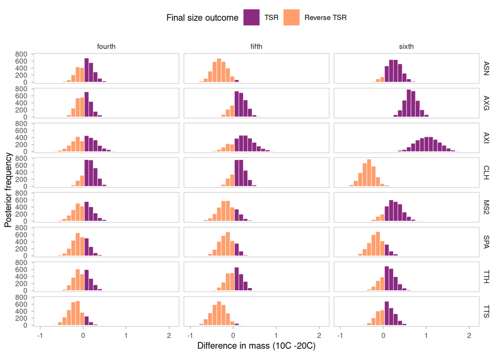

```r
pattern_within_p <- plot_posteriors(
  dat = post_final_mass,
  x = post_final_mass$diff,
  colors = "A",
  x_label = "Difference in mass (10C -20C)",
  low_label = "TSR",
  high_label = "Reverse TSR",
  main = "Final size outcome"
)

pattern_within_p
```

```r
#ggsave("../output/pattern_within_posteriors.pdf", pattern_within_p, device = "pdf", width = 180, height = 200, units = "mm", dpi = 600)
```

Compute support

```r
post_mass_summ <- post_final_mass %>% group_by(species,instar) %>%
  summarise(mean = mean(diff),
            lwr = HPDinterval(mcmc(diff))[1],
            upr = HPDinterval(mcmc(diff))[2],
            P_tsr = sum((diff) < 0)/3000) # P of greater mass in warmer T

post_mass_summ %>% kbl(digits=3) %>%
  kable_styling(
    bootstrap_options = c("striped", "hover", "condensed"),
    full_width = FALSE,
    position = "center",
    font_size = 12
  )
```

| species | instar | mean | lwr | upr | P_tsr |
| --- | --- | --- | --- | --- | --- |
| ASN | fourth | 0.049 | -0.286 | 0.400 | 0.381 |
| ASN | fifth | -0.310 | -0.627 | 0.043 | 0.959 |
| ASN | sixth | 0.237 | -0.137 | 0.556 | 0.090 |
| AXG | fourth | 0.011 | -0.271 | 0.319 | 0.472 |
| AXG | fifth | 0.130 | -0.187 | 0.432 | 0.209 |
| AXG | sixth | 0.644 | 0.362 | 0.966 | 0.000 |
| AXI | fourth | 0.033 | -0.459 | 0.546 | 0.454 |
| AXI | fifth | 0.210 | -0.296 | 0.724 | 0.219 |
| AXI | sixth | 1.026 | 0.507 | 1.581 | 0.000 |
| CLH | fourth | 0.141 | -0.162 | 0.414 | 0.175 |
| CLH | fifth | 0.122 | -0.148 | 0.433 | 0.214 |
| CLH | sixth | -0.354 | -0.654 | -0.033 | 0.984 |
| MS2 | fourth | -0.003 | -0.404 | 0.388 | 0.506 |
| MS2 | fifth | -0.140 | -0.535 | 0.246 | 0.759 |
| MS2 | sixth | 0.233 | -0.155 | 0.635 | 0.131 |
| SPA | fourth | -0.065 | -0.418 | 0.256 | 0.647 |
| SPA | fifth | -0.143 | -0.498 | 0.170 | 0.784 |
| SPA | sixth | -0.141 | -0.492 | 0.200 | 0.787 |
| TTH | fourth | -0.023 | -0.358 | 0.318 | 0.552 |
| TTH | fifth | 0.025 | -0.321 | 0.340 | 0.449 |
| TTH | sixth | 0.103 | -0.222 | 0.475 | 0.277 |
| TTS | fourth | -0.172 | -0.523 | 0.159 | 0.837 |
| TTS | fifth | -0.337 | -0.679 | 0.003 | 0.970 |
| TTS | sixth | 0.057 | -0.290 | 0.410 | 0.380 |

```r
# write to csv
#write.table(post_mass_summ, file = "../output/TSR_pattern_stage_summary.csv", quote = F, row.names = F, sep = ",")
```

Estimate contrasts

```r
# between acclimation temperatures
temp_cont_size <- post_final_mass %>% group_by(species,instar) %>%
  summarise(mean_size = mean(diff),
            lwr_size = HPDinterval(mcmc(diff))[1],
            upr_size = HPDinterval(mcmc(diff))[2],
            P_size = sum((diff < 0)/3000)) # probability of opposite to TSR

temp_cont_size %>% kbl(digits=3) %>%
  kable_styling(
    bootstrap_options = c("striped", "hover", "condensed"),
    full_width = FALSE,
    position = "center",
    font_size = 12
  )
```

| species | instar | mean_size | lwr_size | upr_size | P_size |
| --- | --- | --- | --- | --- | --- |
| ASN | fourth | 0.049 | -0.286 | 0.400 | 0.381 |
| ASN | fifth | -0.310 | -0.627 | 0.043 | 0.959 |
| ASN | sixth | 0.237 | -0.137 | 0.556 | 0.090 |
| AXG | fourth | 0.011 | -0.271 | 0.319 | 0.472 |
| AXG | fifth | 0.130 | -0.187 | 0.432 | 0.209 |
| AXG | sixth | 0.644 | 0.362 | 0.966 | 0.000 |
| AXI | fourth | 0.033 | -0.459 | 0.546 | 0.454 |
| AXI | fifth | 0.210 | -0.296 | 0.724 | 0.219 |
| AXI | sixth | 1.026 | 0.507 | 1.581 | 0.000 |
| CLH | fourth | 0.141 | -0.162 | 0.414 | 0.175 |
| CLH | fifth | 0.122 | -0.148 | 0.433 | 0.214 |
| CLH | sixth | -0.354 | -0.654 | -0.033 | 0.984 |
| MS2 | fourth | -0.003 | -0.404 | 0.388 | 0.506 |
| MS2 | fifth | -0.140 | -0.535 | 0.246 | 0.759 |
| MS2 | sixth | 0.233 | -0.155 | 0.635 | 0.131 |
| SPA | fourth | -0.065 | -0.418 | 0.256 | 0.647 |
| SPA | fifth | -0.143 | -0.498 | 0.170 | 0.784 |
| SPA | sixth | -0.141 | -0.492 | 0.200 | 0.787 |
| TTH | fourth | -0.023 | -0.358 | 0.318 | 0.552 |
| TTH | fifth | 0.025 | -0.321 | 0.340 | 0.449 |
| TTH | sixth | 0.103 | -0.222 | 0.475 | 0.277 |
| TTS | fourth | -0.172 | -0.523 | 0.159 | 0.837 |
| TTS | fifth | -0.337 | -0.679 | 0.003 | 0.970 |
| TTS | sixth | 0.057 | -0.290 | 0.410 | 0.380 |

```r
#write.table(temp_cont_size, "../output/temperature_contrasts_mass.csv", row.names = F, quote = F, sep = ",")

# re-process model results to compute contrasts between stages
post_stage_size <-  process_mass_stage_glmm(mcmc = m2$Sol, post_n = post_n, n_species = 8, n_stages =3, n_traits = 1, n_temp = 2)

# between stages
#t1 = fifth - fourth (transition 1); t2 = sixth - fifth (transition 2)
stage_cont_size <- post_stage_size %>%
  group_by(species, temp) %>%
  summarise(mean_t1 = mean(t1),
            lwr_t1 = HPDinterval(mcmc(t1))[1],
            upr_t1 = HPDinterval(mcmc(t1))[2],
            P_t1= 1- sum((t1 < 0)/3000),
            mean_t2 = mean( t2),
            lwr_t2 = HPDinterval(mcmc( t2))[1],
            upr_t2 = HPDinterval(mcmc( t2))[2],
            P_t2 = 1- sum(( t2 < 0)/3000))

stage_cont_size %>% kbl(digits=3) %>%
  kable_styling(
    bootstrap_options = c("striped", "hover", "condensed"),
    full_width = FALSE,
    position = "center",
    font_size = 12
  )
```

| species | temp | mean_t1 | lwr_t1 | upr_t1 | P_t1 | mean_t2 | lwr_t2 | upr_t2 | P_t2 |
| --- | --- | --- | --- | --- | --- | --- | --- | --- | --- |
| ASN | t10 | 0.183 | -0.157 | 0.506 | 0.868 | 1.274 | 0.956 | 1.605 | 1.000 |
| ASN | t20 | 0.542 | 0.187 | 0.879 | 0.999 | 0.727 | 0.350 | 1.117 | 1.000 |
| AXG | t10 | 0.537 | 0.251 | 0.805 | 1.000 | 1.072 | 0.761 | 1.397 | 1.000 |
| AXG | t20 | 0.418 | 0.085 | 0.741 | 0.994 | 0.557 | 0.244 | 0.908 | 0.998 |
| AXI | t10 | 0.193 | -0.378 | 0.744 | 0.756 | 1.500 | 0.949 | 2.095 | 1.000 |
| AXI | t20 | 0.015 | -0.454 | 0.441 | 0.527 | 0.685 | 0.243 | 1.163 | 0.999 |
| CLH | t10 | 0.338 | 0.059 | 0.624 | 0.992 | 0.814 | 0.520 | 1.152 | 1.000 |
| CLH | t20 | 0.358 | 0.052 | 0.659 | 0.992 | 1.290 | 0.934 | 1.591 | 1.000 |
| MS2 | t10 | 0.466 | 0.068 | 0.855 | 0.992 | 1.082 | 0.687 | 1.518 | 1.000 |
| MS2 | t20 | 0.603 | 0.217 | 0.998 | 0.998 | 0.709 | 0.300 | 1.160 | 0.999 |
| SPA | t10 | 0.364 | -0.012 | 0.701 | 0.978 | 0.821 | 0.465 | 1.175 | 1.000 |
| SPA | t20 | 0.442 | 0.113 | 0.753 | 0.996 | 0.819 | 0.464 | 1.158 | 1.000 |
| TTH | t10 | 0.306 | -0.054 | 0.654 | 0.949 | 1.126 | 0.755 | 1.480 | 1.000 |
| TTH | t20 | 0.258 | -0.048 | 0.593 | 0.945 | 1.048 | 0.713 | 1.385 | 1.000 |
| TTS | t10 | 0.259 | -0.076 | 0.632 | 0.929 | 1.127 | 0.751 | 1.467 | 1.000 |
| TTS | t20 | 0.425 | 0.095 | 0.754 | 0.993 | 0.734 | 0.367 | 1.079 | 1.000 |

```r
#write.table(stage_cont_size, "../output/development_contrasts_mass.csv", row.names = F, quote = F, sep = ",")
```

# Full growth period

Next we look at the entire growth period from the start of the fourth instar to end of the last nymph instar.

## Prepare data

```r
# first we exclude adults
dat_full <- dat_l %>%
  group_by(full_id, species, acclimation) %>%
 # developmental time will be the sum of developmental times across nymph instars
  summarise(Days = sum(Days),
             # mass will be the final mass of the last instar
            Mass = Mass[Instar == "sixth"],
            # the starting mass will be the starting mass for the fourth instar
            StartM = StartM[Instar == "fourth"]) %>%
  # re calculate rates
  mutate(GR = (Mass/Days),DR = 1/Days, Instar = "All")
```

## Thermal sensitivity of development and growth rates

Center and scale rate variables to make them comparable. This also removes two data points with instantaneous development.

```r
dat_full_proc <- prep_rate_dat (data = dat_full, dev_rate=dat_full$DR, growth_rate = dat_full$GR)
```

### Analysis

Estimate species and trait specific slopes with MCMCglmm. “acclimation” is treated as a factor, so we will obtain posterior distributions for rates at 10 and 20 C, and then compute their difference to obtain a posterior distribution for each trait-specific slope.

```r
# MCMCglmm hates tibble
class(dat_full_proc) <- "data.frame"

# acclimation as factor
dat_full_proc$acclimation <- as.factor(dat_full_proc$acclimation)

# we are not interested in fixed effects per se
m3 <- MCMCglmm(value ~ species:rate:acclimation - 1,
               # but we want to estimate species-specific rates at each temperature
               random = ~ species + full_id,
               ginverse=list(species=inv.phylo$Ainv),
               # assuming here that the errors follow a normal distr
               family = "gaussian",
               data = dat_full_proc,
               prior = pr1,
               pl = TRUE,
               slice = TRUE,
               nitt = post_n*thin + burnin,
               burnin = burnin,
               thin = thin,
               verbose = F
)
```

Quick mcmc diagnostics – everything looks good enough, not printing results

### Processing output

Organize and compute posterior distributions of interest.

```r
n_species = 8
n_traits = 2
n_temp = 2

post_full_final <- dplyr::select(data.frame(m3$Sol), contains("acclimation")) %>%
    # reshape into long format
    pivot_longer(cols = everything(),
                 names_to = "rate",
                 values_to = "value") %>%
    # shorten strings
    mutate(rate = gsub("species|rate|acclimation", "", rate)) %>%
    # separate "rate" column into three columns, one for each variable
    separate_wider_delim(
      col = rate,
      delim = ".",
      names = c("species", "trait", "temp")
    ) %>%
    # sort values by species, trait, and temperature (changed "acclimation" for "temp")
    arrange(species, trait, temp)  %>%
    # add a character to make values into strings
    mutate(temp = paste0("t", temp)) %>%
    # create column for iteration id
    mutate(it = rep(seq(1:post_n), n_species * n_traits * n_temp)) %>%
    # make columns for rates at each temp
    pivot_wider(names_from = temp, values_from = value) %>%
    # compute difference in rates between temps (slope)
    mutate(slope = t20 - t10) %>%
    # select columns of interest
    dplyr::select(it, species, trait, slope) %>%
    # make columns for trait-specific slopes
    pivot_wider(names_from = trait, values_from = slope) %>%
    # compute difference in slope between traits
    mutate(rule = dev - growth) %>%
    # create a column to store sign of eact posterior sample
    mutate(sign = ifelse(rule > 0, "expected", "opposite"))

post_full_final$instar <- "All"
```

Plot posterior distributions of reaction norm differences between developmental and growth rate. Positive values indicate a growth/development process consistent with TSR.

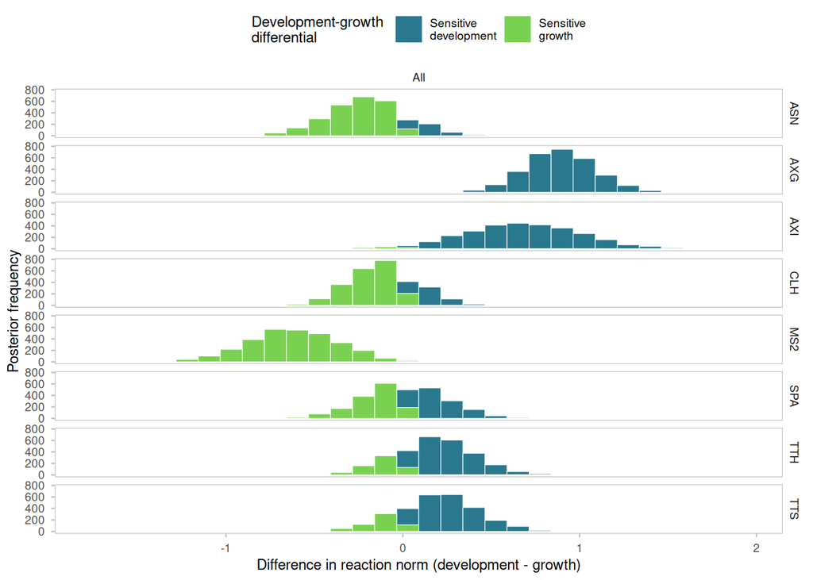

```r
process_full_across_p <- plot_posteriors(
  data = post_full_final,
  x = post_full_final$rule,
  colors = "D",
  x_label = "Difference in reaction norm (development - growth)",
   low_label = "Sensitive\ndevelopment",
  high_label = "Sensitive\ngrowth",
  main = "Development-growth \ndifferential"
)

process_full_across_p
```

```r
#ggsave("../output/process_full_across_posteriors.pdf", process_full_across_p, device = "pdf", width = 90, height = 200, units = "mm", dpi = 600)
```

Compute support

```r
post_full_summ <- post_full_final %>% group_by(species,instar) %>%
  summarise(mean = mean(dev - growth),
            lwr = HPDinterval(mcmc(dev - growth))[1],
            upr = HPDinterval(mcmc(dev - growth))[2],
            P_tsr = sum((dev - growth) < 0)/3000) # probability of opposite to TSR

post_full_summ %>% kbl(digits=3) %>%
  kable_styling(
    bootstrap_options = c("striped", "hover", "condensed"),
    full_width = FALSE,
    position = "center",
    font_size = 12
  )
```

| species | instar | mean | lwr | upr | P_tsr |
| --- | --- | --- | --- | --- | --- |
| ASN | All | -0.197 | -0.628 | 0.229 | 0.811 |
| AXG | All | 0.889 | 0.520 | 1.292 | 0.000 |
| AXI | All | 0.668 | -0.049 | 1.280 | 0.028 |
| CLH | All | -0.103 | -0.475 | 0.248 | 0.711 |
| MS2 | All | -0.617 | -1.098 | -0.105 | 0.991 |
| SPA | All | 0.010 | -0.423 | 0.455 | 0.484 |
| TTH | All | 0.167 | -0.274 | 0.570 | 0.225 |
| TTS | All | 0.184 | -0.264 | 0.614 | 0.203 |

```r
# write to csv
#write.table(post_full_summ, file = "../output/TSR_process_full_summary.csv", quote = F, row.names = F, sep = ",")
```

Estimate contrasts

```r
# between acclimation temperatures

temp_cont_full <- post_full_final %>% group_by(species,instar) %>%
  summarise(mean_dev = mean(dev),
            lwr_dev = HPDinterval(mcmc(dev))[1],
            upr_dev = HPDinterval(mcmc(dev))[2],
            P_dev = sum((dev < 0)/3000),
            mean_gr = mean(growth),
            lwr_gr = HPDinterval(mcmc(growth))[1],
            upr_gr = HPDinterval(mcmc(growth))[2],
            P_gr = sum((growth < 0)/3000),) # probability of opposite to TSR

temp_cont_full %>% kbl(digits=3) %>%
  kable_styling(
    bootstrap_options = c("striped", "hover", "condensed"),
    full_width = FALSE,
    position = "center",
    font_size = 12
  )
```

| species | instar | mean_dev | lwr_dev | upr_dev | P_dev | mean_gr | lwr_gr | upr_gr | P_gr |
| --- | --- | --- | --- | --- | --- | --- | --- | --- | --- |
| ASN | All | 2.120 | 1.682 | 2.534 | 0 | 2.316 | 1.889 | 2.735 | 0 |
| AXG | All | 2.278 | 1.907 | 2.650 | 0 | 1.388 | 1.019 | 1.777 | 0 |
| AXI | All | 2.103 | 1.458 | 2.751 | 0 | 1.435 | 0.788 | 2.077 | 0 |
| CLH | All | 1.416 | 1.076 | 1.811 | 0 | 1.519 | 1.120 | 1.858 | 0 |
| MS2 | All | 1.539 | 1.066 | 2.027 | 0 | 2.156 | 1.675 | 2.686 | 0 |
| SPA | All | 1.448 | 1.042 | 1.867 | 0 | 1.438 | 0.995 | 1.843 | 0 |
| TTH | All | 1.502 | 1.089 | 1.946 | 0 | 1.335 | 0.915 | 1.776 | 0 |
| TTS | All | 1.840 | 1.420 | 2.276 | 0 | 1.656 | 1.230 | 2.088 | 0 |

```r
#write.table(temp_cont_full, "../output/temperature_contrasts_full.csv", row.names = F, quote = F, sep = ",")
```

## Final size outcome

Center and scale mass so we can look at patterns across species.

```r
# zero - centered and scaled to SD
dat_full <-transform(dat_full, z_score=ave(dat_full$Mass,  FUN=scale))
dat_full <-transform(dat_full, z_cov=ave(dat_full$StartM,  FUN=scale))
```

### Analysis

Estimate species-specific “acclimation” effect with MCMCglmm. “acclimation” is treated as a factor, so we will obtain posterior distributions for final mass at the end of the last instar at 10 and 20 C, and then compute the differences in mass to obtain a posterior distribution for each species-specific effect of temperature.

```r
dat_full$acclimation <- as.factor(dat_full$acclimation)

# we are not interested in fixed effects per se
m4 <- MCMCglmm(z_score ~ species:acclimation + z_cov -1,
               # but we want to estimate species-specific rates at each temperature
               random = ~ species + full_id,
               ginverse=list(species=inv.phylo$Ainv),
               # assuming here that the errors follow a normal distr
               family = "gaussian",
               data = dat_full,
               prior = pr1,
               pl = TRUE,
               slice = TRUE,
               nitt = post_n*thin + burnin,
               burnin = burnin,
               thin = thin,
               # save species-specific estimates
               verbose = F
)
```

Quick mcmc diagnostics – everything looks good, not printing results

```r
#traceplot(m4$Sol)
```

### Processing output

Organize and compute posterior distributions of interest.

```r
n_traits = 1

# select species-specific estimates
post_full_mass <- dplyr::select(data.frame(m4$Sol), contains("acclimation")) %>%
    # reshape into long format
    pivot_longer(cols = everything(), names_to = "mass", values_to = "value") %>%
    # shorten strings
    mutate(mass = gsub("species|acclimation", "", mass)) %>%
    # separate "rate" column into three columns, one for each variable
    separate_wider_delim(col = mass, delim = ".", names = c("species","temp")) %>%
    # sort values by species, and temperature (changed "acclimation" for "temp")
    arrange(species, temp)  %>%
    # add a character to make values into strings
    mutate(temp = paste0("t", temp)) %>%
    # create column for iteration id
    mutate(it = rep(seq(1:post_n),n_species*n_traits*n_temp)) %>%
    # make columns for rates at each temp
    pivot_wider(names_from = temp, values_from = value) %>%
    # compute difference in rates between temps (slope)
    mutate(diff = t10 - t20) %>%
    # select columns of interest
   dplyr::select(it, species, diff) %>%
    # make columns for trait-specific slopes
    # pivot_wider(names_from = trait, values_from = diif) %>%
    # compute difference in slope between traits
    # mutate(rule = dev - growth) %>%
    # create a column to store sign of each posterior sample
    mutate(sign = ifelse(diff > 0, "expected", "opposite"))


post_full_mass$instar <- "All"
#head(post_final_mass)
```

Plot posterior distributions of mass differences between temperature treatments. Positive values indicate TSR (larger at lower temperature).

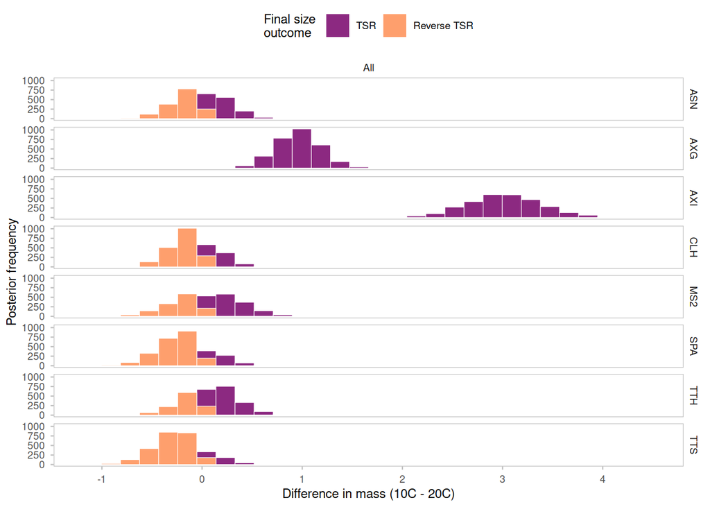

```r
pattern_full_across_p <- plot_posteriors(
  dat = post_full_mass,
  x = post_full_mass$diff,
  colors = "A",
  x_label = "Difference in mass (10C - 20C)",
  low_label = "TSR",
  high_label = "Reverse TSR",
  main = "Final size \noutcome"
)

pattern_full_across_p
```

```r
#ggsave("../output/pattern_full_across_posteriors.pdf", pattern_full_across_p, device = "pdf", width = 90, height = 200, units = "mm", dpi = 600)
```

Compute support

```r
post_full_mass_summ <- post_full_mass %>% group_by(species,instar) %>%
  summarise(mean = mean(diff),
            lwr = HPDinterval(mcmc(diff))[1],
            upr = HPDinterval(mcmc(diff))[2],
            P_tsr = sum((diff) < 0)/3000) # P of greater mass in warmer T

post_full_mass_summ %>% kbl(digits=3) %>%
  kable_styling(
    bootstrap_options = c("striped", "hover", "condensed"),
    full_width = FALSE,
    position = "center",
    font_size = 12
  )
```

| species | instar | mean | lwr | upr | P_tsr |
| --- | --- | --- | --- | --- | --- |
| ASN | All | -0.014 | -0.503 | 0.465 | 0.518 |
| AXG | All | 0.960 | 0.533 | 1.398 | 0.000 |
| AXI | All | 3.018 | 2.330 | 3.793 | 0.000 |
| CLH | All | -0.079 | -0.525 | 0.316 | 0.653 |
| MS2 | All | 0.051 | -0.565 | 0.648 | 0.440 |
| SPA | All | -0.165 | -0.625 | 0.379 | 0.751 |
| TTH | All | 0.073 | -0.406 | 0.573 | 0.376 |
| TTS | All | -0.220 | -0.694 | 0.280 | 0.811 |

```r
# write to csv
# write.table(post_full_mass_summ, file = "../output/TSR_pattern_full_summary.csv", quote = F, row.names = F, sep = ",")
```

Estimate contrasts

```r
# between acclimation temperatures
temp_cont_full_mass <- post_full_mass %>% group_by(species,instar) %>%
  summarise(mean_diff = mean(diff),
            lwr_diff = HPDinterval(mcmc(diff))[1],
            upr_diff = HPDinterval(mcmc(diff))[2],
            P_diff = sum((diff < 0)/3000)) # probability of opposite to TSR

temp_cont_full_mass %>% kbl(digits=3) %>%
  kable_styling(
    bootstrap_options = c("striped", "hover", "condensed"),
    full_width = FALSE,
    position = "center",
    font_size = 12
  )
```

| species | instar | mean_diff | lwr_diff | upr_diff | P_diff |
| --- | --- | --- | --- | --- | --- |
| ASN | All | -0.014 | -0.503 | 0.465 | 0.518 |
| AXG | All | 0.960 | 0.533 | 1.398 | 0.000 |
| AXI | All | 3.018 | 2.330 | 3.793 | 0.000 |
| CLH | All | -0.079 | -0.525 | 0.316 | 0.653 |
| MS2 | All | 0.051 | -0.565 | 0.648 | 0.440 |
| SPA | All | -0.165 | -0.625 | 0.379 | 0.751 |
| TTH | All | 0.073 | -0.406 | 0.573 | 0.376 |
| TTS | All | -0.220 | -0.694 | 0.280 | 0.811 |

```r
#write.table(temp_cont_full_mass, "../output/temperature_contrasts_full_mass.csv", row.names = F, quote = F, sep = ",")
```

# TSR evolution

## Prep data

Compile mean estimates from all models

```r
tree_file <- "../data/raw/stick_tree.tre"

tree <- read.tree(tree_file)

process_stage <- post_summ %>%
  dplyr::select(c(species,instar,mean)) %>%
  pivot_wider(names_from = instar, values_from = mean) %>%
  rename(fourth_process = fourth, fifth_process = fifth, last_process = sixth)

pattern_stage <- post_mass_summ %>%
  dplyr::select(c(species,instar,mean)) %>%
  pivot_wider(names_from = instar, values_from = mean) %>%
  rename(fourth_pattern = fourth, fifth_pattern = fifth, last_pattern = sixth)

process_full <- post_full_summ %>%
  dplyr::select(c(species,instar,mean)) %>%
  pivot_wider(names_from = instar, values_from = mean) %>%
  rename(full_process = All)

pattern_full <- post_full_mass_summ %>%
  dplyr::select(c(species,instar,mean)) %>%
  pivot_wider(names_from = instar, values_from = mean) %>%
  rename(full_pattern = All)

traits <- left_join(process_stage, pattern_stage) %>%
  left_join(process_full) %>%
  left_join(pattern_full) %>%
   arrange(match(species,tree$tip.label))

# untibble this for phytools
traits <- data.frame(traits)
```

## ASE

Estimate ancestral states

```r
if (!all(tree$tip.label %in% traits$species)) stop("Some tree tips are missing in CSV")

output_list <- list()
n_traits <- ncol(traits)
ncol_layout <- 2
nrow_layout <- ceiling(n_traits / ncol_layout)

# Compute global min/max for consistent color scale
all_process_values <- c()
for(trait_name in colnames(traits)[c(2:4,8)]) {
  x <- as.numeric(traits[, trait_name])
  names(x) <- traits$species
  anc <- fastAnc(tree, x)
  all_process_values <- c(all_process_values, x, anc)
}

global_process_min <- min(all_process_values)
global_process_max <- max(all_process_values)

all_pattern_values <- c()
for(trait_name in colnames(traits)[c(5:7,9)]) {
  x <- as.numeric(traits[, trait_name])
  names(x) <- traits$species
  anc <- fastAnc(tree, x)
  all_pattern_values <- c(all_pattern_values, x, anc)
}

global_pattern_min <- min(all_pattern_values)
global_pattern_max <- max(all_pattern_values)


n_nodes <- tree$Nnode + length(tree$tip.label)

all_values <- c(all_process_values, all_pattern_values)

n_nodes <- tree$Nnode + length(tree$tip.label)

node_list <- split(all_values, ceiling(seq_along(all_values) / 15))
```

## Final plot

Development-growth differential fourth instar

```r
titles <- c("Development-growth differential",  "Final size outcome")

sig_tips_names_1 <- post_summ$species[post_summ$instar == "fourth" & (post_summ$P_tsr < 0.05 | post_summ$P_tsr > 0.95) ]
sig_tips_1 <- rep(4, 15)
names(sig_tips_1) <- c(tree$tip.label,seq(from = 9 , to = 15, by = 1))
sig_tips_1[names(sig_tips_1) %in% sig_tips_names_1] <- 6

near_sig_tips_names_1 <- post_summ$species[post_summ$instar == "fourth" & (post_summ$P_tsr < 0.1 & post_summ$P_tsr > 0.05  | post_summ$P_tsr < 0.95 & post_summ$P_tsr > 0.90) ]
near_sig_tips_1 <- rep(4, 15)
names(near_sig_tips_1) <- c(tree$tip.label,seq(from = 9 , to = 15, by = 1))
near_sig_tips_1[names(near_sig_tips_1) %in% near_sig_tips_names_1] <- 5

proc_4 <- ggtree(tree) +
  geom_tiplab(size = 2, offset = .001) +
  geom_nodepoint(size = 4) +
  geom_nodepoint(aes(colour = unlist(node_list[[1]])), size = 3.5) +
  geom_tippoint(aes(size = sig_tips_1), color = "grey20") +
  #geom_tippoint(aes(size = near_sig_tips_1), color = "grey20") +
  geom_tippoint(aes(colour = unlist(node_list[[1]])), size = 3.5) +
  scale_color_viridis(option = "viridis",  limits = c(global_process_min, global_process_max), begin = 0.3) +
  scale_size_continuous(range = c(4, 5.5),guide = "none") +
  labs(title = titles[1], subtitle = "Fourth", color = "") +
   theme(plot.title = element_text(hjust = 0.5)) +
  theme(
  legend.position = c(0, 1),
    legend.justification = c(0, .7),
  legend.key.size = unit(0.35, 'cm'),
  legend.background = element_blank(),
   plot.title = element_text(size = 11, face = "bold"),
  plot.subtitle = element_text(hjust = 0.5))
```

Development-growth differential fith instar

```r
sig_tips_names_2 <- post_summ$species[post_summ$instar == "fifth" & (post_summ$P_tsr < 0.05 | post_summ$P_tsr > 0.95) ]
sig_tips_2 <- rep(4, 15)
names(sig_tips_2) <- c(tree$tip.label,seq(from = 9 , to = 15, by = 1))
sig_tips_2[names(sig_tips_2) %in% sig_tips_names_2] <- 6

near_sig_tips_names_2 <- post_summ$species[post_summ$instar == "fifth" & (post_summ$P_tsr < 0.1 & post_summ$P_tsr > 0.05  | post_summ$P_tsr < 0.95 & post_summ$P_tsr > 0.90) ]
near_sig_tips_2 <- rep(4, 15)
names(near_sig_tips_2) <- c(tree$tip.label,seq(from = 9 , to = 15, by = 1))
near_sig_tips_2[names(near_sig_tips_2) %in% near_sig_tips_names_2] <- 5

proc_5 <- ggtree(tree) +
  geom_tiplab(size = 2, offset = .001) +
  geom_nodepoint(size = 4) +
  geom_nodepoint(aes(colour = unlist(node_list[[2]])), size = 3.5) +
  geom_tippoint(aes(size = sig_tips_2), color = "grey20") +
 # geom_tippoint(aes(size = near_sig_tips_2), color = "grey20") +
  geom_tippoint(aes(colour = unlist(node_list[[2]])), size = 3.5) +
  scale_color_viridis(option = "viridis",  limits = c(global_process_min, global_process_max), begin = 0.3) +
   scale_size_continuous(range = c(4, 5.5),guide = "none") +
  labs(title = "",  subtitle = "Fifth", color = "") +
   theme(plot.title = element_text(hjust = 0.5)) +
  theme(
  legend.position = c(0, 1),
    legend.justification = c(0, .7),
  legend.key.size = unit(0.35, 'cm'),
  legend.background = element_blank(),
   plot.title = element_text(size = 11, face = "bold"),
  plot.subtitle = element_text(hjust = 0.5))
```

Development-growth differential sixth instar

```r
sig_tips_names_3 <- post_summ$species[post_summ$instar == "sixth" & (post_summ$P_tsr < 0.05 | post_summ$P_tsr > 0.95) ]
sig_tips_3 <- rep(4, 15)
names(sig_tips_3) <- c(tree$tip.label,seq(from = 9 , to = 15, by = 1))
sig_tips_3[names(sig_tips_3) %in% sig_tips_names_3] <- 6

near_sig_tips_names_3 <- post_summ$species[post_summ$instar == "sixth" & (post_summ$P_tsr < 0.1 & post_summ$P_tsr > 0.05  | post_summ$P_tsr < 0.95 & post_summ$P_tsr > 0.90) ]
near_sig_tips_3 <- rep(4, 15)
names(near_sig_tips_3) <- c(tree$tip.label,seq(from = 9 , to = 15, by = 1))
near_sig_tips_3[names(near_sig_tips_3) %in% near_sig_tips_names_3] <- 5

proc_6 <- ggtree(tree) +
  geom_tiplab(size = 2, offset = .001) +
  geom_nodepoint(size = 4) +
  geom_tippoint(size = 4) +
  geom_nodepoint(aes(colour = unlist(node_list[[3]])), size = 3.5) +
  #geom_tippoint(aes(size = sig_tips_3), color = "grey20") +
  #geom_tippoint(aes(size = near_sig_tips_3), color = "grey20") +
  geom_tippoint(aes(colour = unlist(node_list[[3]])), size = 3.5) +
   scale_color_viridis(option = "viridis",  limits = c(global_process_min, global_process_max), begin = 0.3) +
  # scale_size_continuous(range = c(4, 5.5),guide = "none") +
  labs( title = "", subtitle = "Sixth", color = "") +
   theme(plot.title = element_text(hjust = 0.5))+
  theme(
  legend.position = c(0, 1),
    legend.justification = c(0, .7),
  legend.key.size = unit(0.35, 'cm'),
  legend.background = element_blank(),
   #plot.title = element_text(size = 11, face = "bold"),
  plot.subtitle = element_text(hjust = 0.5))
```

Development-growth differential full period

```r
sig_tips_names_4 <- post_full_summ$species[post_full_summ$P_tsr < 0.05 | post_full_summ$P_tsr > 0.95 ]
sig_tips_4 <- rep(4, 15)
names(sig_tips_4) <- c(tree$tip.label,seq(from = 9 , to = 15, by = 1))
sig_tips_4[names(sig_tips_4) %in% sig_tips_names_4] <- 6

near_sig_tips_names_4 <- post_full_summ$species[post_full_summ$P_tsr < 0.1 & post_full_summ$P_tsr > 0.05  | post_full_summ$P_tsr < 0.95 & post_full_summ$P_tsr > 0.90]
near_sig_tips_4 <- rep(4, 15)
names(near_sig_tips_4) <- c(tree$tip.label,seq(from = 9 , to = 15, by = 1))
near_sig_tips_4[names(near_sig_tips_4) %in% near_sig_tips_names_4] <- 5

proc_all <- ggtree(tree) +
  geom_tiplab(size = 2, offset = .001) +
  geom_nodepoint(size = 4) +
  geom_nodepoint(aes(colour = unlist(node_list[[4]])), size = 3.5) +
  geom_tippoint(aes(size = sig_tips_4), color = "grey20") +
 # geom_tippoint(aes(size = near_sig_tips_4), color = "grey20") +
  geom_tippoint(aes(colour = unlist(node_list[[4]])), size = 3.5) +
   scale_color_viridis(option = "viridis",  limits = c(global_process_min, global_process_max), begin = 0.3) +
   scale_size_continuous(range = c(4, 5.5),guide = "none") +
  labs(title = "", subtitle = "All",  color = "") +
   theme(plot.title = element_text(hjust = 0.5)) +
  theme(
  legend.position = c(0, 1),
    legend.justification = c(0, .7),
  legend.key.size = unit(0.35, 'cm'),
  legend.background = element_blank(),
   plot.title = element_text(size = 11, face = "bold"),
  plot.subtitle = element_text(hjust = 0.5))
```

Final size outcome fourth instar

```r
sig_tips_names_5 <- post_mass_summ$species[post_mass_summ$instar == "fourth" & (post_mass_summ$P_tsr < 0.05 | post_mass_summ$P_tsr > 0.95) ]
sig_tips_5 <- rep(4, 15)
names(sig_tips_5) <- c(tree$tip.label,seq(from = 9 , to = 15, by = 1))
sig_tips_5[names(sig_tips_5) %in% sig_tips_names_5] <- 6

near_sig_tips_names_5 <- post_mass_summ$species[post_mass_summ$instar == "fourth" & (post_mass_summ$P_tsr < 0.1 & post_mass_summ$P_tsr > 0.05  | post_mass_summ$P_tsr < 0.95 & post_mass_summ$P_tsr > 0.90) ]
near_sig_tips_5 <- rep(4, 15)
names(near_sig_tips_5) <- c(tree$tip.label,seq(from = 9 , to = 15, by = 1))
near_sig_tips_5[names(near_sig_tips_5) %in% near_sig_tips_names_5] <- 5

pattern_4 <- ggtree(tree) +
  geom_tiplab(size = 2, offset = -.004) +
  geom_nodepoint(size = 4) +
  geom_tippoint(size = 4) +
  geom_nodepoint(aes(colour = unlist(node_list[5])), size = 3.5) +
  #geom_tippoint(aes(size = sig_tips_5), color = "grey20") +
  #geom_tippoint(aes(size = near_sig_tips_5), color = "grey20") +
  geom_tippoint(aes(colour = unlist(node_list[5])), size = 3.5) +
   scale_color_viridis(option = "magma",  limits = c(global_pattern_min, global_pattern_max), begin = 0.3) +
   scale_size_continuous(range = c(4, 5.5),guide = "none") +
  scale_x_reverse() +
 labs(title = titles[2], subtitle = "Fourth", color = "") +
  theme(plot.title = element_text(hjust = 0.5)) +
  theme(
  legend.position = c(1, 1),
    legend.justification = c(1, .7),
  legend.key.size = unit(0.35, 'cm'),
  legend.background = element_blank(),
   plot.title = element_text(size = 11, face = "bold"),
  plot.subtitle = element_text(hjust = 0.5))
```

Final size outcome fifth instar

```r
sig_tips_names_6 <- post_mass_summ$species[post_mass_summ$instar == "fifth" & (post_mass_summ$P_tsr < 0.05 | post_mass_summ$P_tsr > 0.95) ]
sig_tips_6 <- rep(4, 15)
names(sig_tips_6) <- c(tree$tip.label,seq(from = 9 , to = 15, by = 1))
sig_tips_6[names(sig_tips_6) %in% sig_tips_names_6] <- 6

near_sig_tips_names_6 <- post_mass_summ$species[post_mass_summ$instar == "fifth" & (post_mass_summ$P_tsr < 0.1 & post_mass_summ$P_tsr > 0.05  | post_mass_summ$P_tsr < 0.95 & post_mass_summ$P_tsr > 0.90) ]
near_sig_tips_6 <- rep(4, 15)
names(near_sig_tips_6) <- c(tree$tip.label,seq(from = 9 , to = 15, by = 1))
near_sig_tips_6[names(near_sig_tips_6) %in% near_sig_tips_names_6] <- 5

pattern_5 <- ggtree(tree) +
  geom_tiplab(size = 2, offset = -.004) +
  geom_nodepoint(size = 4) +
  geom_nodepoint(aes(colour = unlist(node_list[6])), size = 3.5) +
  geom_tippoint(aes(size = sig_tips_6), color = "grey20") +
  #geom_tippoint(aes(size = near_sig_tips_6), color = "grey20") +
  geom_tippoint(aes(colour = unlist(node_list[6])), size = 3.5) +
   scale_color_viridis(option = "magma",  limits = c(global_pattern_min, global_pattern_max), begin = 0.3) +
  scale_x_reverse() +
   scale_size_continuous(range = c(4, 5.5),guide = "none") +
 labs(title = "",  subtitle = "Fifth", color = "") +
   theme(plot.title = element_text(hjust = 0.5)) +
  theme(
  legend.position = c(1, 1),
    legend.justification = c(1, .7),
  legend.key.size = unit(0.35, 'cm'),
  legend.background = element_blank(),
   plot.title = element_text(size = 11, face = "bold"),
  plot.subtitle = element_text(hjust = 0.5))
```

Final size outcome sixth instar

```r
sig_tips_names_7 <- post_mass_summ$species[post_mass_summ$instar == "sixth" & (post_mass_summ$P_tsr < 0.05 | post_mass_summ$P_tsr > 0.95) ]
sig_tips_7 <- rep(4, 15)
names(sig_tips_7) <- c(tree$tip.label,seq(from = 9 , to = 15, by = 1))
sig_tips_7[names(sig_tips_7) %in% sig_tips_names_7] <- 6

near_sig_tips_names_7 <- post_mass_summ$species[post_mass_summ$instar == "sixth" & (post_mass_summ$P_tsr < 0.1 & post_mass_summ$P_tsr > 0.05  | post_mass_summ$P_tsr < 0.95 & post_mass_summ$P_tsr > 0.90) ]
near_sig_tips_7 <- rep(4, 15)
names(near_sig_tips_7) <- c(tree$tip.label,seq(from = 9 , to = 15, by = 1))
near_sig_tips_7[names(near_sig_tips_7) %in% near_sig_tips_names_7] <- 5

pattern_6 <- ggtree(tree) +
  geom_tiplab(size = 2, offset = -.004) +
  geom_nodepoint(size = 4) +
  geom_nodepoint(aes(colour = unlist(node_list[7])), size = 3.5) +
  geom_tippoint(aes(size = sig_tips_7), color = "grey20") +
  #geom_tippoint(aes(size = near_sig_tips_7), color = "grey20") +
  geom_tippoint(aes(colour = unlist(node_list[7])), size = 3.5) +
   scale_color_viridis(option = "magma",  limits = c(global_pattern_min, global_pattern_max), begin = 0.3) +
   scale_size_continuous(range = c(4, 5.5),guide = "none") +
  scale_x_reverse() +
   scale_size_continuous(range = c(4, 5.5),guide = "none") +
 labs(title = "", subtitle = "Sixth", color = "") +
   theme(plot.title = element_text(hjust = 0.5)) +
  theme(
  legend.position = c(1, 1),
    legend.justification = c(1, .7),
  legend.key.size = unit(0.35, 'cm'),
  legend.background = element_blank(),
   plot.title = element_text(size = 11, face = "bold"),
  plot.subtitle = element_text(hjust = 0.5))
```

Final size outcome full period

```r
sig_tips_names_8 <- post_full_mass_summ$species[(post_full_mass_summ$P_tsr < 0.05 | post_full_mass_summ$P_tsr > 0.95) ]
sig_tips_8 <- rep(4, 15)
names(sig_tips_8) <- c(tree$tip.label,seq(from = 9 , to = 15, by = 1))
sig_tips_8[names(sig_tips_8) %in% sig_tips_names_8] <- 6

near_sig_tips_names_8 <- post_full_mass_summ$species[(post_full_mass_summ$P_tsr < 0.1 & post_full_mass_summ$P_tsr > 0.05  | post_full_mass_summ$P_tsr < 0.95 & post_full_mass_summ$P_tsr > 0.90) ]
near_sig_tips_8 <- rep(4, 15)
names(near_sig_tips_8) <- c(tree$tip.label,seq(from = 9 , to = 15, by = 1))
near_sig_tips_8[names(near_sig_tips_8) %in% near_sig_tips_names_8] <- 5

pattern_all <- ggtree(tree) +
  geom_tiplab(size = 2, offset = -.004) +
  geom_nodepoint(size = 4) +
  geom_nodepoint(aes(colour = unlist(node_list[8])), size = 3.5) +
  geom_tippoint(aes(size = sig_tips_8), color = "grey20") +
  #geom_tippoint(aes(size = near_sig_tips_7), color = "grey20") +
  geom_tippoint(aes(colour = unlist(node_list[8])), size = 3.5) +
   scale_color_viridis(option = "magma",  limits = c(global_pattern_min, global_pattern_max), begin = 0.3) +
  scale_x_reverse() +
   scale_size_continuous(range = c(4, 5.5),guide = "none") +
 labs(title = "", subtitle = "All", color = "") +
   theme(plot.title = element_text(hjust = 0.5)) +
  theme(
  legend.position = c(1, 1),
  legend.justification = c(1, .7),
  legend.key.size = unit(0.35, 'cm'),
  legend.background = element_blank(),
   plot.title = element_text(size = 11, face = "bold"),
  plot.subtitle = element_text(hjust = 0.5))
```

Plot all

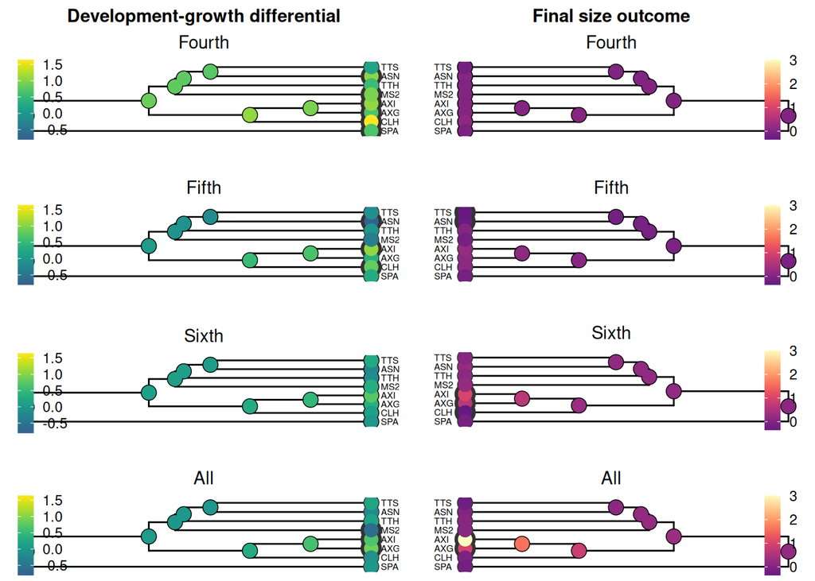

```r
plot_list <- list(proc_4, pattern_4, proc_5, pattern_5, proc_6, pattern_6, proc_all, pattern_all)

grid <- grid.arrange(grobs=plot_list, ncol=2)
```

```r
#ggsave(grid, filename = "../output/ASE_v3.pdf", device = "pdf", width = 180, height = 220, units = "mm", dpi = 600)
```